# Déterminants sociaux du comportement sexuel et reproductif chez les femmes en République Démocratique du Congo, EDS 2013-2014

ZAWADI Merveille

2025-09-04

# INTRODUCTION

La sexualité et la fécondité sont des dimensions centrales de la vie humaine, influencées par des facteurs culturels, économiques et sociaux. En RDC, pays marqué par une grande diversité ethnique, religieuse et géographique, les comportements liés au premier rapport sexuel et à la procréation varient considérablement selon les individus. L’âge du premier rapport sexuel, souvent considéré comme un indicateur de maturité sexuelle et de vulnérabilité, peut être influencé par le niveau d’éducation, la religion, le milieu de résidence (rural ou urbain), la province d’origine et le statut socio-économique. De même, le nombre d’enfants qu’un individu a au cours de sa vie est souvent le reflet de normes sociales, d’accès à l’information et aux services de santé, ainsi que de choix personnels façonnés par le contexte.

Cette étude vise à explorer les liens entre ces variables sociodémographiques et les comportements sexuels et reproductifs, en mettant l’accent sur l’âge du premier rapport sexuel, le nombre d’enfants et l’utilisation de la contraception. Elle cherche à identifier les facteurs les plus déterminants et à comprendre comment ils interagissent pour influencer les trajectoires de vie des individus en RDC.

## Contexte et justification.

Dans de nombreux contextes africains, les comportements sexuels et reproductifs sont influencés par une multitude de facteurs sociodémographiques. En RDC, les disparités liées à l’éducation, à la religion, au milieu de résidence et à la richesse peuvent jouer un rôle déterminant dans l’âge du premier rapport sexuel et le nombre d’enfants. Pourtant, peu d’études approfondissent l’interaction entre ces variables et leurs effets combinés sur le devenir de la vie reproductive des femmes. Il devient donc essentiel de comprendre comment ces facteurs façonnent les choix et les réalités des femmes, afin d’orienter les politiques de santé sexuelle et reproductive.

### Hypothèse.

Les facteurs sociodémographiques tels que le niveau d’éducation, la religion, le milieu de résidence (rural/urbain) et l’indice de richesse influencent significativement l’âge du premier rapport sexuel et le nombre d’enfants chez les adultes en RDC.

## Objectifs de l’étude.

### Objectif général.

Nous analyserons principalement l’influence des facteurs sociodémographiques sur l’âge du premier rapport sexuel et le nombre d’enfants chez les adultes en RDC.

### Objectifs spécifiques.

D’une manière spécifique, nous allons :

- **Décrire le profil sociodémographique** des individus en fonction de leur âge, niveau d’éducation, religion, province d’origine, milieu rural ou urbain, et indice de richesse.
- Examiner la relation entre **le niveau d’éducation et l’âge du premier rapport sexuel.**
- Évaluer l’impact du **milieu de résidence (rural vs urbain) sur le nombre d’enfants.**
- Analyser l’effet de la **religion sur les comportements sexuels et reproductifs.**
- Étudier l’association entre **l’indice de richesse et les indicateurs de fécondité.**
- Identifier les facteurs les plus déterminants dans la variation de **l’âge du premier rapport sexuel et du nombre d’enfants.**

# METHODE.

## La source des données.

Les enquêtes démographiques et sanitaires (EDS), en anglais Demographic and Health Surveys (DHS) sont une série d’enquêtes standardisées menées périodiquement dans les pays en développement afin de collecter des données sur divers aspects de la population, de la santé et de la nutrition

Nous travaillerons sur les données de la RDC comme présenté ci-haut dans la problématique. [L’accès à la base de données des EDS par pays](https://drive.google.com/drive/u/0/folders/1J0gw4qpfbB8bYFbXx8QcsQEWgJSVwp_P) ainsi que le [guide des statistiques du DHS](https://dhsprogram.com/data/Guide-to-DHS-Statistics/) vous sont partages pour toutes fins utiles.

## Les variables de l’etude.

- **Variables dépendantes** : Âge du premier rapport sexuel et Nombre d’enfants
- **Variables indépendantes** : Âge, niveau d’éducation, religion, province d’origine, milieu rural/urbain, indice de richesse, type de contraception et crainte des effets secondaires.

### Description des caractéristiques sociodémographiques de la population d’étude et des relations entre elles et les variables dependantes.

#### *Description de la variable Âge*

La distribution de la variable âge est etonnament assymétrique bien que 28 ans est l’âge moyen et 27ans l’âge médian soient proche.

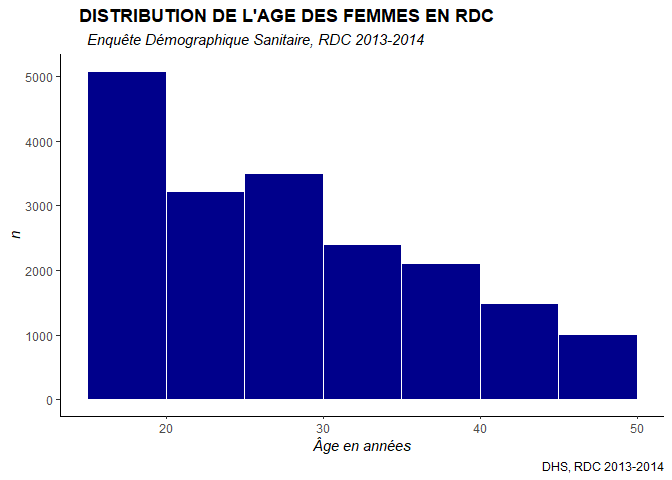

Les moins de 30 ans représentaient la majorité de la population féminine de la RDC en 2013-2014.

#### *Description de la variable “Âge du premier rapport sexuel”*

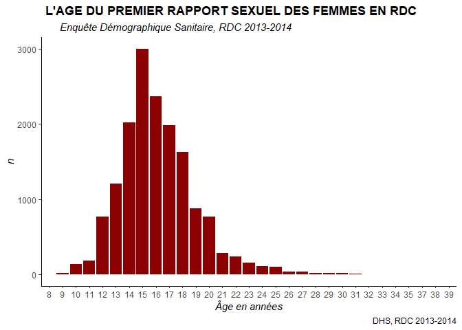

#### *Description de la variable nombres d’enfants vivants par femme : la Parité*

Pour analyser la variable nombres d’enfants qui est numérique, nous avons cree une nouvelle variable catégorielle dite parité qui est defini sur base du nombre d’enfants. Elle se définira comme suit : - **Nulliparité** : aucun enfant vivant (nombres d’enfants inferieur 1), - **Pauci parité** : nombres d’enfants inferieur a 3 et supérieur ou égale à 1, - **Multiparité** : nombres d’enfants inferieur a 5 et supérieur ou égale à 3 et - **Grande multiparité** : nombres d’enfants supérieur ou égale à 5.

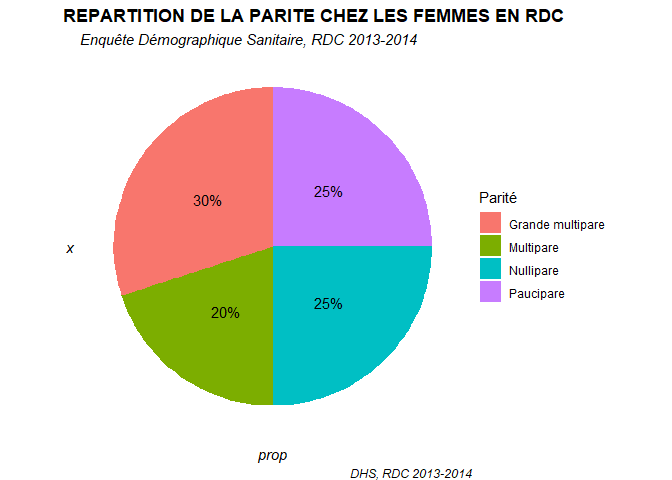

La grande multiparité est la plus représentée, ce qui est en adéquation avec les analyses précédentes, une population relativement jeune et qui débute la vie sexuelle assez tôt.

### Influence et Relation entre les variables.

#### *Le niveau d’éducation par milieu d’habitation*

| milieu | niveau_education | nombre |
| --- | --- | --- |
| urban | no education | 376 |
| urban | primary | 1563 |
| urban | secondary | 4341 |
| urban | higher | 547 |
| rural | no education | 2981 |
| rural | primary | 5757 |
| rural | secondary | 3248 |
| rural | higher | 14 |

Cette population majoritairement rurale n’a pas atteint le niveau supérieur d’éducation contrairement à la population urbaine ou les deux tiers ont un niveau secondaire et un bon nombre de ceux qui ont un niveau universitaire.

#### *Religion et sexualité*

Les normes religieuses peuvent encourager l’abstinence jusqu’au mariage, ce qui tend à retarder l’âge du premier rapport sexuel chez les personnes pratiquantes.

Aussi, Officiellement l’Église catholique s’oppose à la contraception artificielle et ne promeut que les méthodes naturelles comme l’abstinence périodique, considérée comme une atteinte à l’ordre naturel et au dessein divin de procréation mais le débats internes de certains théologiens et fidèles plaident pour une approche plus souple, mettant en avant la responsabilité parentale et la santé des femmes.

Tandis que chez les protestants la position est variée. De nombreuses dénominations protestantes autorisent la contraception, la considérant comme une décision personnelle entre les partenaires ainsi la planification familiale est vue comme un moyen responsable de gérer les naissances et de préserver la santé des familles.

L’islam n’interdit pas la contraception mais les avis varient selon les écoles juridiques. Elle est souvent autorisée si elle ne nuit pas à la santé, si elle est temporaire et décidée en accord entre époux.

| Religion | n | (%) |
| --- | --- | --- |
| other christians | 6,782 | 36.0 |
| catholic | 5,434 | 28.9 |
| protestant | 5,243 | 27.8 |
| kimbanguiste | 562 | 3.0 |
| muslim | 290 | 1.5 |
| other | 175 | 0.9 |
| no religion | 164 | 0.9 |
| animist | 70 | 0.4 |
|  | 47 | 0.2 |
| armée de salut | 33 | 0.2 |
| bundu dia kongo | 22 | 0.1 |
| vuvamu | 5 | 0.0 |

Les chrétiennes constituent la quasi-totalité de cette population avec quelques minorités d’autres religions représentées.

#### *La contraception et la religion*

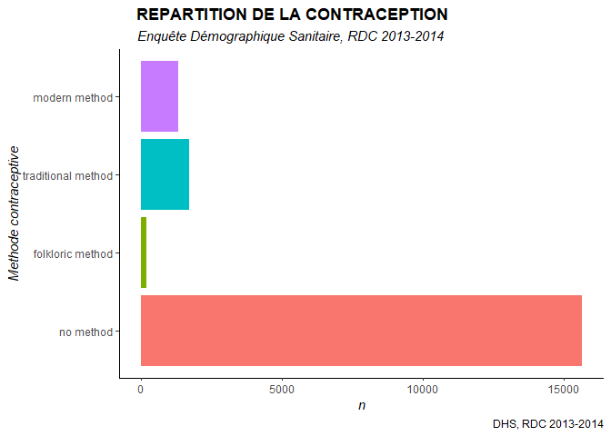

Cette population congolaise chrétienne relativement jeune qui débute la vie sexuelle assez tôt n’utilise aucune contraception (utilisation des méthodes modernes que par un petit nombre).

#### *Relation entre l’indice de richesse et le type de contraception utilisée*

Grâce au soutien de bailleurs internationaux (comme l’USAID), certaines méthodes contraceptives sont gratuites dans les centres de santé publics et privées. Et le montant reste dérisoire s’il faut payer, ou du moins accessible financièrement une grande majorité de la population.

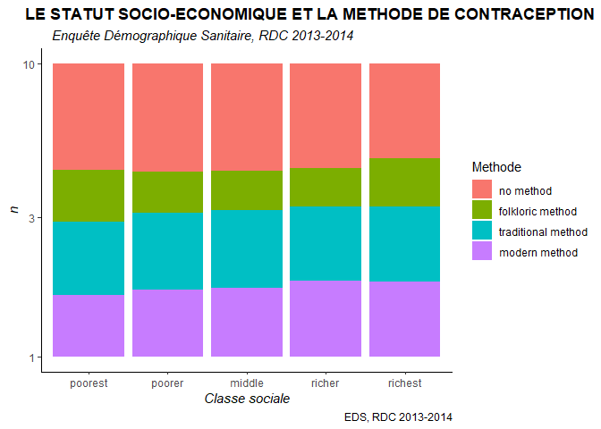

On observe qu’il y a une légère tendance à la hausse en terme d’utilisation des méthodes modernes en passant du statut économique très pauvre à celui de très riche (une analyse statistique avancée nous démontrerais si cette différence est alors statistiquement significative) mais s’explique ce que nous avons avance plus haut en rapport avec l’accessibilite financiere.

Et donc a priori, l’abscence de l’utilisation de contraception n’est forcément pas liée au statut socioéconomique.Qu’en est-il de la parité.

#### *La pariTé et le statut socio-economique*

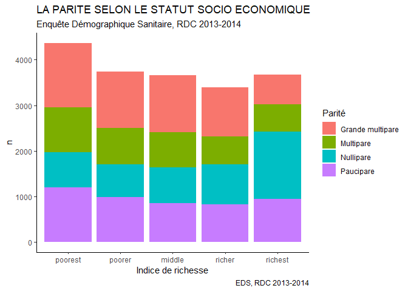

Paradoxalement, les pauvres et ceux qui sont très pauvres sont ceux qui ont le plus des enfants tandis que pour les très riches, la catégorie nullipare est la plus représentée.

#### *Distribution de l’âge du premier rapport sexuel par niveau d’éducation*

[figure not shown]

Le premier rapport sexuel semble relativement tardif chez les femmes qui ont un niveau d’éducation supérieur comparativement aux autres catégories.

#### *L’impact du milieu de résidence (rural vs urbain) sur le nombre d’enfants.*

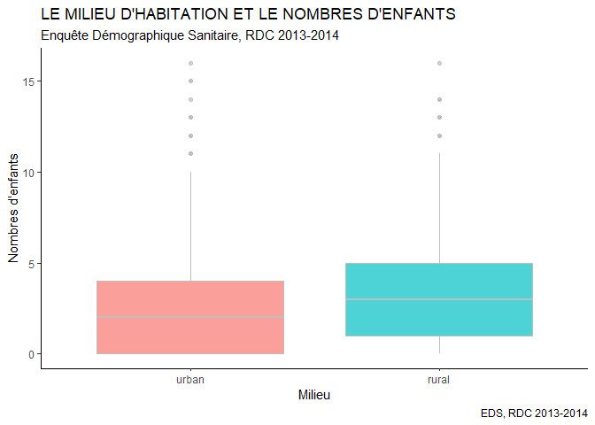

Les femmes du milieu rural ont une médiane du nombres d’enfants plus élevée que les celles du milieu urbain.

# CONCLUSION

La quasi-totalité de la population étudiée se réclame du christianisme, ce qui souligne l’importance des normes religieuses dans la construction des trajectoires reproductives. Toutefois, l’usage des méthodes contraceptives modernes reste marginal, bien qu’une légère progression soit observée chez les femmes issues des milieux économiquement favorisés. Ce gradient suggère que l’accessibilité financière joue un rôle dans l’adoption des pratiques contraceptives, sans pour autant garantir leur généralisation.

Enfin, le paradoxe entre richesse et fécondité où les femmes les plus pauvres ont davantage d’enfants tandis que les plus riches sont majoritairement nullipares illustre les inégalités structurelles qui traversent la société congolaise. Ces résultats appellent à une réflexion approfondie sur les politiques de santé sexuelle et reproductive, en particulier sur l’éducation, l’accès aux services de santé, et la réduction des disparités territoriales et économiques.